# Rapport mondial sur l’évolution des attitudes face au divorce

L’exemple de l’Allemagne

Author

Nassim ADJMI

On se propose dans la présente note d’étudier l’évolution mondiale des opinions sur le divorce. Nous allons pour cela utiliser les réponses à la question suivante

*“Sur une échelle de 1 à 10, diriez vous que :”*

-*Le divorce n’est jamais justifié (1)*

-*Le divorce est toujours justifié (10)*

## Préparation des données

Nous allons travailler ici sur les données de la **World Value Survey** en considérant deux vagues d’enquêtes séparées de 25 ans (une génération) ce qui permettra de détecter d’éventuelles évolutions dans les opinions.

- 1990-1998
- 2017-2022

### Opinions sur le divorce en 1990-98

```
5859 missing rows in the "opi_divo" column have been removed.
```

### Opinions sur le divorce en 2017-2022

```
816 missing rows in the "opi_divo" column have been removed.
```

# ANALYSE DE l’Allemagne

## INTRODUCTION

Nous allons étudier l’opinion sur le divorce et son évolution dans le pays suivant : Allemagne

L’Allemagne constitue un cas d’étude particulièrement pertinent pour analyser l’évolution des attitudes face au divorce. En tant que société européenne marquée à la fois par une forte institutionnalisation de la famille et par **des transformations profondes des normes sociales** au cours des dernières décennies, elle offre un terrain d’observation privilégié des **changements de valeurs** liés à la vie conjugale.

Cette analyse s’appuie sur les données de la **World Values Survey (WVS)**, une enquête internationale de référence visant à mesurer les valeurs, croyances et attitudes des populations dans de nombreux pays. La WVS permet d’étudier de manière comparative et diachronique l’évolution des opinions individuelles sur des enjeux sociaux majeurs, tels que la famille, le mariage et le divorce.

Depuis la fin du XXᵉ siècle, **l’Allemagne a connu d’importantes évolutions sociales, juridiques et culturelles concernant la famille et les trajectoires conjugales.** L’opinion publique à l’égard du divorce est susceptible de refléter ces transformations, notamment dans un contexte de montée de l’individualisation, d’élévation du niveau d’éducation et de recomposition des rôles sociaux.

Nous proposons donc d’étudier l’opinion sur le divorce et son évolution en Allemagne à partir de deux vagues de la World Values Survey, séparées d’environ une génération (1990-1998 et 2017-2022), afin d’identifier les changements globaux des attitudes et d’analyser la manière dont celles-ci se structurent selon **différentes caractéristiques sociodémographiques.**

### Echantillon

Notre échantillon se compose de 1979 en 1990-98 et 1524 en 2017-2022

### Recodage des variables

On décide de recoder la variable initiale en deux nouvelles variables :

- opi_niv : regroupement des opinions en 2 à 5 niveaux
- opi_pol : regroupement des opinions extrêmes contre modérées
- **Justification** :

L’opinion sur le divorce est mesurée à l’aide d’une échelle de Likert allant de 1 à 10, où 1 correspond à « le divorce n’est jamais justifié » et 10 à « le divorce est toujours justifié ». Cette variable est qualitative ordonnée.

Travailler directement avec les 10 modalités rend la lecture des résultats difficile et peu lisible, en particulier lorsqu’on souhaite comparer les distributions entre deux périodes. Nous avons donc choisi de regrouper les modalités en un nombre réduit de catégories, tout en conservant le sens de l’échelle initiale.

Le regroupement en niveaux d’opinion permet de dégager plus clairement les grandes tendances (opinions défavorables ou favorables) et de faciliter la comparaison entre les deux vagues d’enquête.

Par ailleurs, une variable de polarisation de l’opinion a été construite afin d’identifier les positions les plus extrêmes. Les modalités 1 et 10 ont été considérées comme des positions extrêmes, tandis que l’ensemble des modalités intermédiaires correspond à des opinions plus nuancées. Ce choix permet d’étudier non seulement l’évolution globale de l’opinion, mais aussi l’évolution de la part des individus exprimant des jugements très tranchés.

Ces choix de recodage visent donc à rendre l’analyse plus lisible et plus interprétable, tout en restant fidèles à l’information contenue dans la variable initiale.

### Hypothèses

Nous proposons de tester les hypothèses suivantes :

- H1 : L’opinion a évolué au cours du temps
- H2 : L’opinion sur le divorce varie selon le sexe
- H3 : L’opinion sur le divorce varie selon l’âge ou la génération
- H4 : L’opinion sur le divorce varie selon le niveau d’éducation

## HYP. 1 : L’OPINION CHANGE AU COURS DU TEMPS

H0 : On suppose que la distribution des opinions sur le divorce en Allemagne est identique en 1990-1998 et en 2017-2022.

### Situation en 1990-1998

#### Niveau

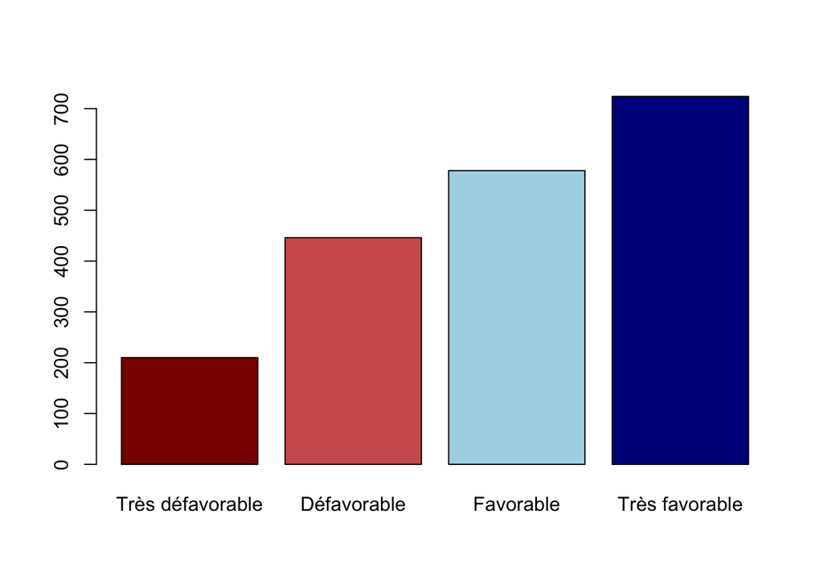

- **Commentaire** : ``

Le graphique met en évidence une opinion **globalement favorable au divorce en Allemagne** dès la période 1990-1998. Les modalités favorables dominent visuellement, en particulier la catégorie très favorable, tandis que les positions défavorables restent bien représentées mais minoritaires.

La distribution suggère donc une société déjà largement ouverte à l’idée du divorce, tout en conservant une diversité d’opinions, avec une présence non négligeable de jugements critiques.

#### Polarisation

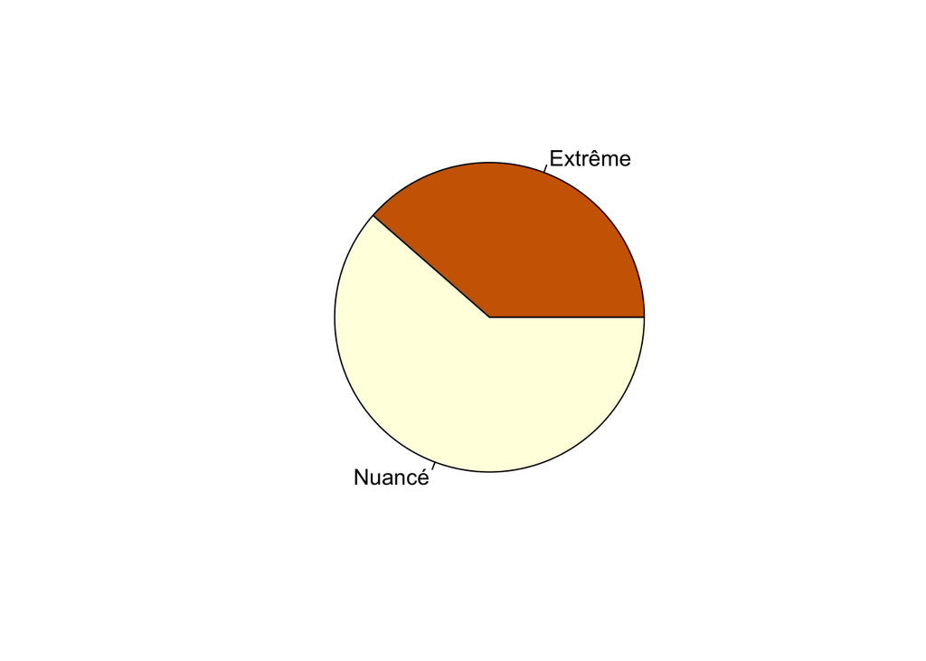

- **Commentaire** :

Le graphique de polarisation montre que la majorité des individus adopte des positions nuancées plutôt que des opinions extrêmes. Les positions radicales existent cependant dans des **proportions importantes**, ce qui indique que le débat sur le divorce suscite déjà des prises de position tranchées chez une partie de la population.

### Situation en 2017-2022

#### Niveau

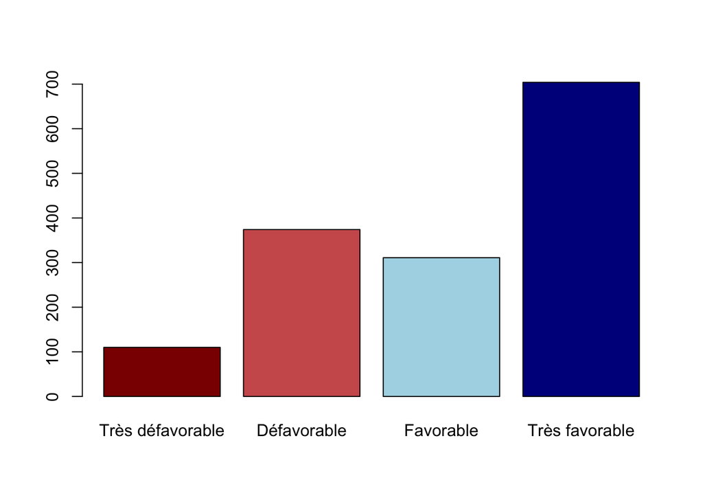

- **Commentaire** :

Le graphique révèle une **forte prédominance des opinions favorables**, et plus particulièrement des positions très favorables. Les opinions défavorables apparaissent moins visibles que lors de la période précédente, tandis que l’adhésion au divorce semble plus affirmée et moins hésitante.

La structure de la distribution suggère une normalisation accrue du divorce dans les représentations sociales.

#### Polarisation

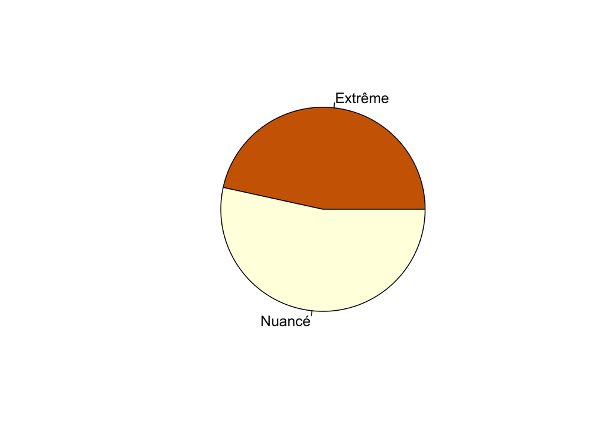

- **Commentaire** :

Le graphique de polarisation indique une **augmentation notable des positions extrêmes.** Les opinions nuancées restent légèrement majoritaires, mais l’écart avec les positions extrêmes se réduit fortement, traduisant une opinion plus polarisée.

Cette configuration suggère que, si le divorce est désormais largement accepté, il suscite également **des positions plus tranchées** qu’auparavant.

### Dynamique d’opinion

#### Niveau

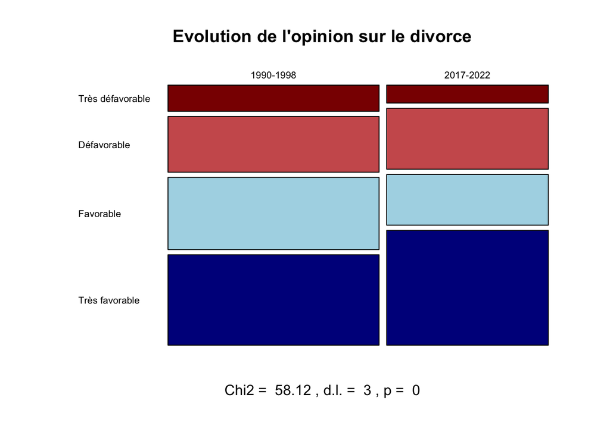

- **Commentaire** :

La comparaison des distributions **entre 1990-1998 et 2017-2022** met en évidence une évolution significative de l’opinion sur **le divorce en Allemagne.** Le test du khi-deux confirme que les différences observées entre les deux périodes ne peuvent pas être attribuées au hasard (χ² = 58,1 ; ddl = 3 ; p < 0,001).

Graphiquement, on observe **une recomposition de l’échelle des opinions.** La part des individus se déclarant très favorables au divorce augmente nettement, tandis que la catégorie favorable recule. Parallèlement, les opinions très défavorables deviennent moins fréquentes, alors que la catégorie défavorable reste relativement stable.

Cette évolution suggère un **déplacement des opinions vers des positions plus affirmées,** en particulier du côté favorable. L’opinion allemande ne se contente pas d’un simple glissement progressif : elle tend à se **repolariser autour des positions extrêmes,** surtout dans le sens d’une justification accrue du divorce.

Le test du khi-deux met en évidence une différence statistiquement très significative entre les deux périodes (p < 0,001). L’hypothèse nulle H0 est donc rejetée. On conclut que la distribution des opinions sur le divorce en Allemagne a significativement évolué entre 1990-1998 et 2017-2022.

#### Polarisation

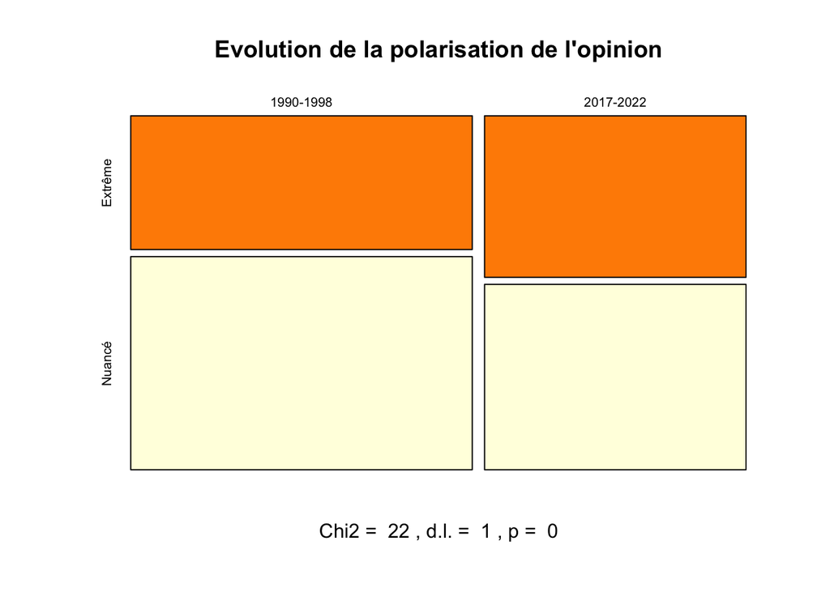

- **Commentaire** :

L’analyse de la polarisation confirme et complète ce diagnostic. La part des opinions extrêmes (réponses 1 et 10 sur l’échelle) augmente significativement entre les deux périodes, **tandis que les opinions nuancées reculent.**

Le test du chi-deux avec correction de continuité de Yates met en évidence une évolution statistiquement très significative de la polarisation de l’opinion (χ² = 22 ; d.l. = 1 ; p < 0,001).

Ainsi, au-delà de l’évolution moyenne des attitudes, l’opinion allemande sur le divorce apparaît plus polarisée en 2017-2022 qu’au début des années 1990. Les individus sont proportionnellement plus nombreux à adopter des positions tranchées, au détriment des jugements intermédiaires.

Cette dynamique indique une structuration plus marquée des opinions, sans présumer des motivations individuelles, mais révélant une transformation du rapport collectif à la norme du divorce.

Le test du khi-deux avec correction de Yates indique une évolution statistiquement significative de la polarisation de l’opinion (p < 0,001). L’hypothèse nulle H0 est rejetée. La part des opinions extrêmes sur le divorce a significativement augmenté entre les deux périodes.

## HYP.2 : L’OPINION VARIE SELON LE SEXE

H0 : On suppose que la distribution des opinions sur le divorce est identique chez les hommes et chez les femmes.

### Situation en 1990-1998

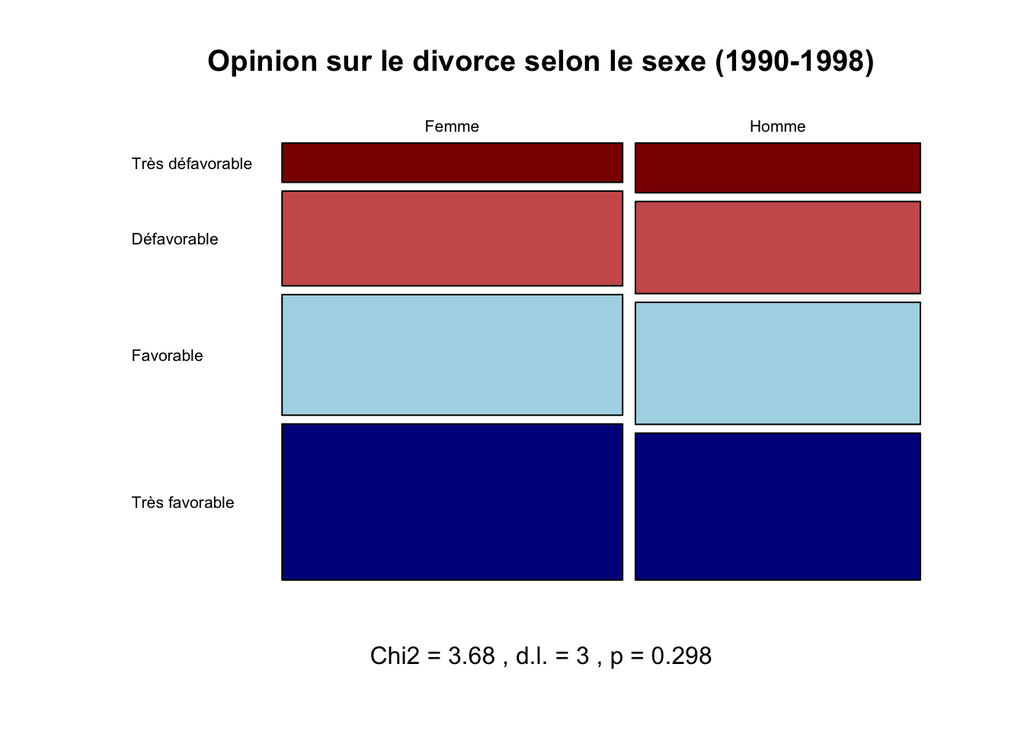

- **Commentaire** :

Le graphique met en évidence des distributions très proches des opinions entre les hommes et les femmes. Les deux sexes présentent une structure comparable de l’échelle d’opinion, avec une majorité relative de positions favorables et très favorables, et des proportions similaires d’opinions défavorables.

Les femmes apparaissent très légèrement plus favorables que les hommes, tandis que ces derniers sont marginalement plus nombreux à exprimer des positions très défavorables. Toutefois, ces écarts restent faibles et ne traduisent pas de différence nette de structure.

Le test du khi-deux confirme cette lecture graphique : χ² = 3,68 ; d.l. = 3 ; p = 0,298.

La p-value étant largement supérieure au seuil usuel de 5 %, **l’hypothèse nulle ne peut pas être rejetée.** On conclut donc qu’en 1990-1998, **l’opinion sur le divorce ne diffère pas significativement selon le sexe** en Allemagne

### Situation en 2017-2022

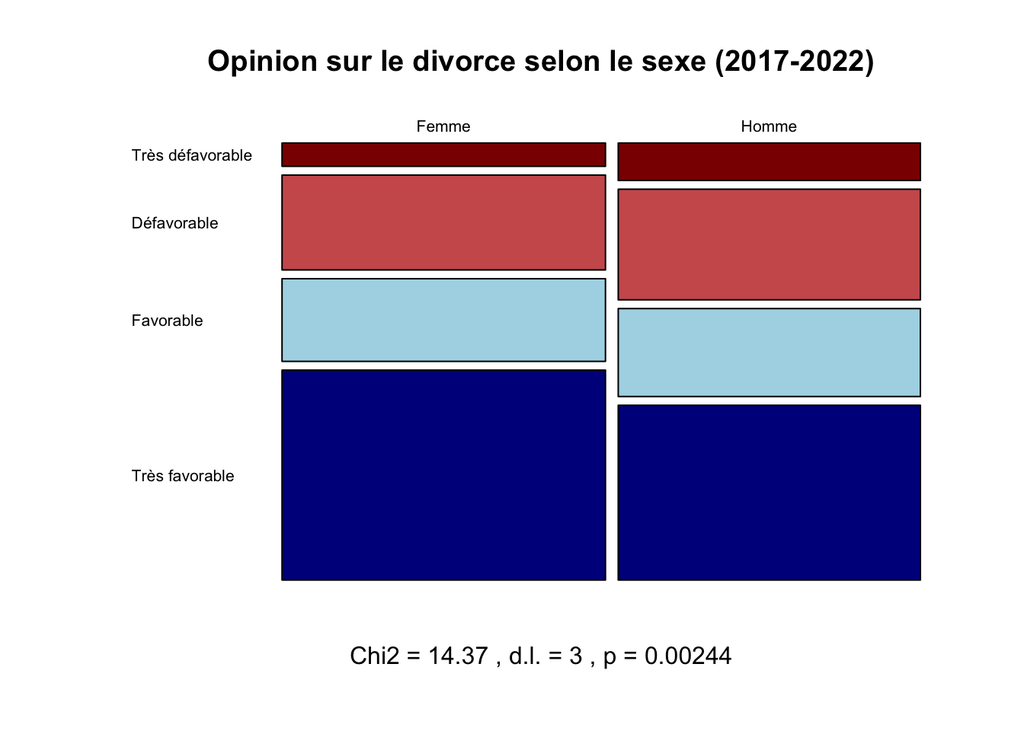

- **Commentaire** :

Le graphique montre en revanche des différences plus marquées entre hommes et femmes. Les femmes se déclarent nettement plus souvent très favorables au divorce, tandis que les hommes sont relativement plus nombreux dans les catégories défavorables et favorables intermédiaires.

La structure globale de l’opinion reste majoritairement favorable pour les deux sexes, mais l’intensité de l’adhésion diffère : les femmes occupent plus fréquemment les positions les plus favorables, alors que les hommes apparaissent plus modérés.

Le test du khi-deux confirme que ces écarts sont statistiquement significatifs : χ² = 14,37 ; d.l. = 3 ; p = 0,002.

La p-value étant inférieure à 1 %, **l’hypothèse nulle est rejetée.** On conclut donc qu’en 2017-2022, **l’opinion sur le divorce varie significativement selon le sexe en Allemagne.**

### Conclusion pour l’hypothèse 2

L’analyse met en évidence une évolution du rôle du sexe dans la structuration des opinions sur le divorce. Alors qu’aucune différence significative n’est observée entre hommes et femmes au début des années 1990, des écarts clairs apparaissent dans la période récente.

Cette dynamique suggère que le sexe devient un facteur plus discriminant dans l’expression des attitudes face au divorce, sans préjuger des mécanismes sous-jacents, mais en révélant une transformation des rapports sociaux à cette norme familiale au cours du temps.

## HYP.3 : L’OPINION VARIE SELON L’ÂGE OU LA GÉNÉRATION

H0 : On suppose que la distribution des opinions sur le divorce est identique quel que soit l’âge des individus ou leur génération de naissance. Cette hypothèse nulle postule l’absence de relation entre l’âge (ou la génération) et l’opinion exprimée sur le divorce.

On regroupe l’âge en trois classes (0–25, 26–60, 61+) afin de comparer des groupes suffisamment fournis et de faciliter l’interprétation. L’objectif est de tester si la distribution des opinions sur le divorce varie selon l’âge.

### Situation en 1990-1998

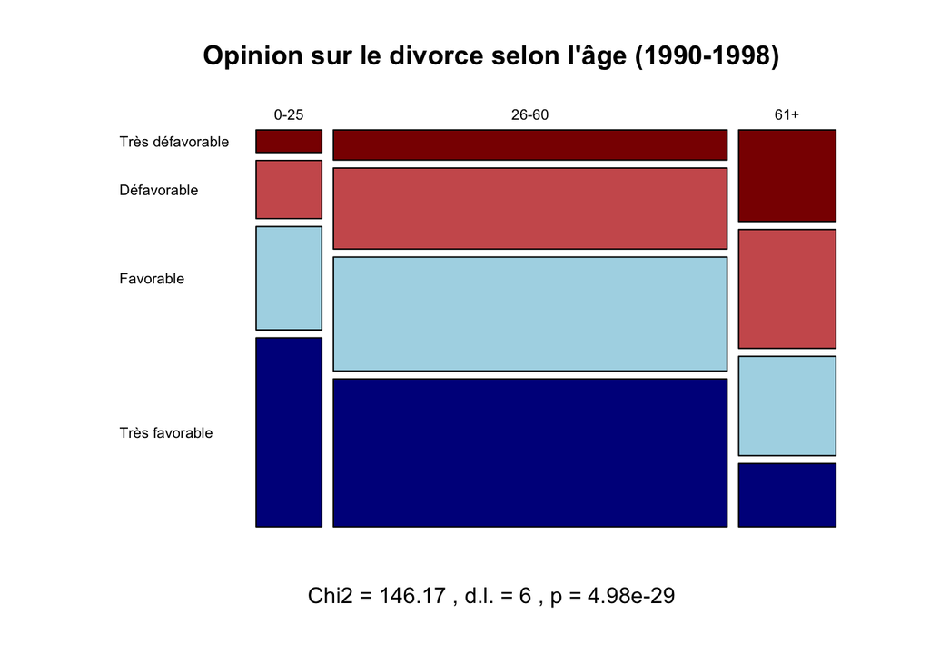

- **Commentaire** :

Le graphique met en évidence de **fortes différences d’opinion selon l’âge en Allemagne au cours de la période 1990-1998.**

**Les jeunes (0-25 ans)** se distinguent par une proportion très élevée d’opinions favorables et très favorables au divorce, traduisant une attitude globalement permissive. **Les adultes (26-60 ans)** adoptent également majoritairement des positions favorables, mais de manière plus modérée. À l’inverse, **les personnes âgées de 61 ans** et plus expriment beaucoup plus fréquemment des opinions défavorables ou très défavorables, et nettement moins d’opinions très favorables.

Le test du khi-deux confirme que ces différences sont hautement significatives (χ² = 146,2 ; ddl = 6 ; p < 0,001). On rejette donc l’hypothèse nulle H0 pour la période 1990-1998.

Ces résultats suggèrent un **fort effet générationnel**, les cohortes les plus jeunes apparaissant déjà beaucoup plus ouvertes au divorce que les générations plus âgées.

### Situation en 2017-2022

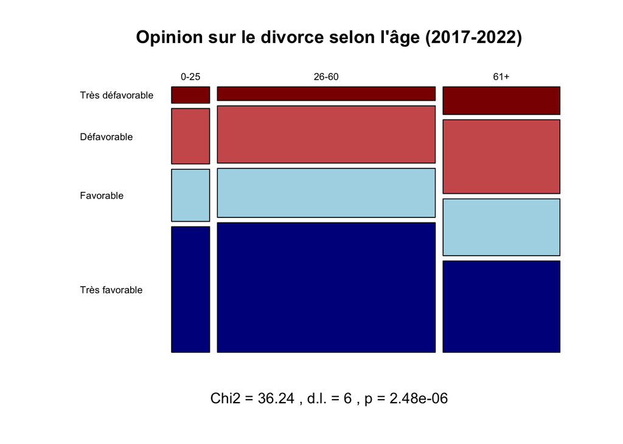

- **Commentaire** :

En 2017-2022, l’opinion sur le divorce reste **significativement liée à l’âge**, mais les écarts entre groupes apparaissent moins marqués qu’au début des années 1990.

Les jeunes et les adultes présentent désormais des profils très proches, caractérisés par une très forte proportion d’opinions très favorables. Les personnes de 61 ans et plus demeurent plus réservées, avec une part plus importante d’opinions défavorables, mais elles apparaissent **néanmoins nettement plus favorables au divorce qu’en 1990-1998.**

Le test du khi-deux indique que les différences observées restent statistiquement significatives (χ² = 36,2 ; ddl = 6 ; p < 0,001). L’hypothèse nulle H0 est à nouveau rejetée pour la période récente.

Cette évolution suggère que si les effets d’âge et de génération persistent, ils tendent à **s’atténuer avec le temps**, sous l’effet d’une diffusion plus large de normes favorables au divorce dans l’ensemble de la société.

|  | Très défavorable | Défavorable | Favorable | Très favorable | Sum |
| --- | --- | --- | --- | --- | --- |
| 1990-1998 | 56 | 166 | 277 | 422 | 921 |
| 2017-2022 | 28 | 135 | 122 | 301 | 586 |
| Sum | 84 | 301 | 399 | 723 | 1507 |

|  | Très défavorable | Défavorable | Favorable | Très favorable | Total |
| --- | --- | --- | --- | --- | --- |
| 1990-1998 | 6.1 | 18 | 30.1 | 45.8 | 100 |
| 2017-2022 | 4.8 | 23 | 20.8 | 51.4 | 100 |
| All | 5.6 | 20 | 26.5 | 48.0 | 100 |

```
    Pearson's Chi-squared test

data:  tab
X-squared = 19.483, df = 3, p-value = 0.0002172
```

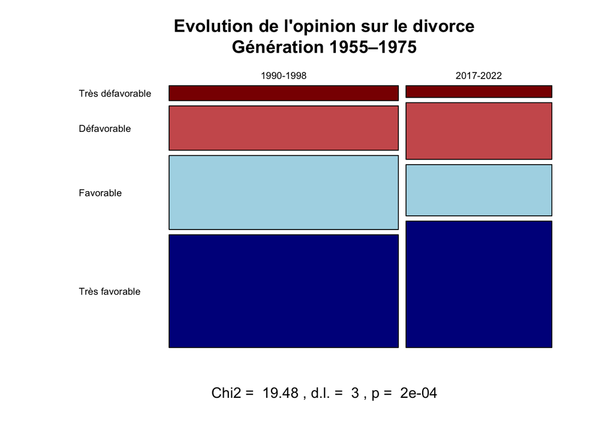

### Analyse Générationnelle

#### Évolution de l’opinion de la génération 1955-1975

- **Commentaire** :

L’analyse générationnelle permet de suivre l’évolution de l’opinion d’un même groupe d’individus observé à deux périodes différentes. Pour **la génération née entre 1955 et 1975**, le test du chi-deux met en évidence une évolution statistiquement significative de l’opinion entre 1990-1998 et 2017-2022 (χ² = 19,5 ; d.l. = 3 ; p < 0,001).

L’hypothèse nulle H0, selon laquelle la distribution des opinions serait identique aux deux périodes pour cette génération, est donc rejetée.

Cette évolution indique que le changement d’attitude ne s’explique pas uniquement par le renouvellement générationnel. À génération constante, les individus ont eux-mêmes modifié leur rapport au divorce au cours du temps, ce qui suggère un effet de contexte social et normatif, indépendant du seul effet de l’âge.

## HYP.4 : L’OPINION VARIE SELON LE NIVEAU D’ÉDUCATION

H0 : On suppose que la distribution des opinions sur le divorce est identique quel que soit le niveau d’éducation des individus. Cette hypothèse nulle postule l’absence de relation entre le niveau d’éducation et l’opinion exprimée sur le divorce.

Avant l’analyse, les individus présentant des valeurs manquantes sur le niveau d’éducation, l’opinion sur le divorce ou le poids d’enquête ont été exclus afin de garantir la cohérence des tableaux et des tests statistiques. Les modalités du niveau d’éducation ont ensuite été conservées sous trois catégories (bas, moyen, haut), avec des effectifs suffisants dans chaque groupe, ce qui permet une comparaison fiable des distributions d’opinion.

### Situation en 1990-1998

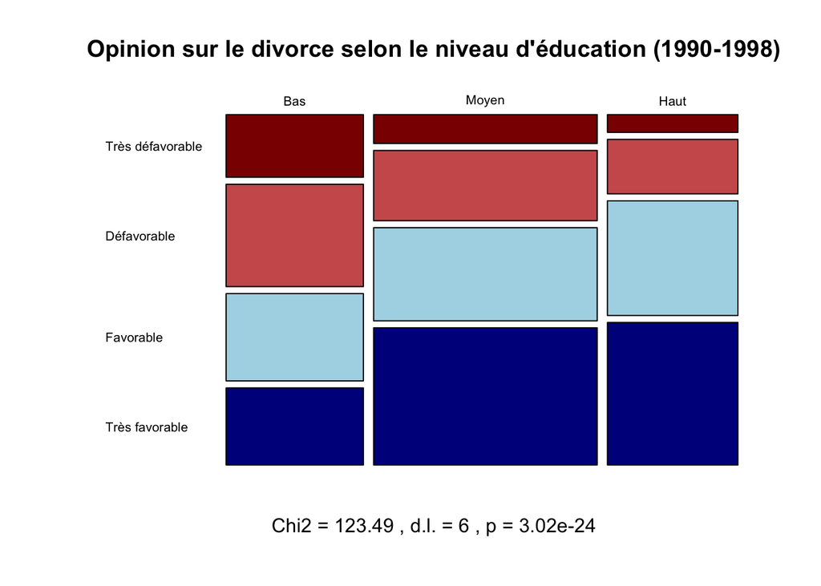

- **Commentaire** :

Le graphique met en évidence **des différences très marquées d’opinion sur le divorce selon le niveau d’éducation en Allemagne au cours de la période 1990-1998.**

Les individus ayant un niveau d’éducation faible expriment beaucoup plus fréquemment des opinions défavorables ou très défavorables au divorce, tandis que les positions très favorables restent minoritaires dans ce groupe. À l’inverse, les personnes ayant un niveau d’éducation moyen ou élevé se caractérisent par une adhésion nettement plus forte au divorce, avec une part importante d’opinions favorables et très favorables, particulièrement élevée parmi les diplômés les plus instruits.

Le test du khi-deux confirme que ces écarts ne sont pas dus au hasard (χ² = 123,5 ; ddl = 6 ; p < 0,001). La p-value étant largement inférieure au seuil de 5 %, l’hypothèse nulle H0 est rejetée.

On conclut donc qu’en 1990-1998, **l’opinion sur le divorce varie significativement selon le niveau d’éducation en Allemagne,** les individus les plus diplômés apparaissant nettement plus favorables au divorce.

### Situation en 2017-2022

[figure not shown]

- **Commentaire** :

En 2017-2022, l’opinion sur le divorce demeure **significativement structurée par le niveau d’éducation**, bien que les écarts soient moins prononcés qu’au début des années 1990.

Les individus les moins diplômés restent plus nombreux à exprimer des opinions défavorables, tandis que les niveaux d’éducation moyen et élevé se distinguent par une forte proportion d’opinions très favorables au divorce. Toutefois, l’adhésion globale au divorce progresse dans l’ensemble des groupes éducatifs, y compris parmi les moins diplômés, traduisant une diffusion plus large de normes favorables.

Le test du khi-deux confirme que les différences observées restent statistiquement significatives (χ² = 29,4 ; ddl = 6 ; p < 0,001). L’hypothèse nulle H0 est à nouveau rejetée.

Ces résultats indiquent que **le niveau d’éducation continue de jouer un rôle dans la structuration des attitudes face au divorce,** même si les écarts tendent à se réduire avec le temps.

### Conclusion H4

**L’analyse met en évidence un effet robuste et persistant du niveau d’éducation sur l’opinion vis-à-vis du divorce en Allemagne.**

Si les individus les plus diplômés apparaissent systématiquement plus favorables au divorce que les moins diplômés, l’évolution temporelle montre une **convergence progressive des opinions,** liée à une acceptation croissante du divorce dans l’ensemble de la société.

Le niveau d’éducation demeure ainsi un facteur discriminant, mais son influence semble s’atténuer au fil du temps, au profit d’une norme sociale plus largement partagée.

## CONCLUSION GENERALE

**Cette analyse, fondée sur deux vagues de la World Value Survey (1990-1998 et 2017-2022), met en évidence une transformation significative des attitudes face au divorce en Allemagne.**

D’abord, l’opinion globale évolue nettement dans le temps : la distribution des réponses change de manière statistiquement significative, ce qui conduit à rejeter l’hypothèse nulle d’une stabilité entre les deux périodes. L’évolution observée se traduit surtout par une progression marquée des positions très favorables au divorce.

Ensuite, **l’étude montre que la structuration sociale de l’opinion n’est pas uniforme.** En 1990-1998, le sexe n’apparaît pas comme un facteur discriminant, mais en 2017-2022, des différences significatives émergent : les femmes se situent plus fréquemment dans les positions les plus favorables. On observe donc un renforcement du lien entre sexe et opinion au cours du temps.

Par ailleurs, l’âge reste un facteur fortement associé aux attitudes face au divorce : les personnes plus âgées demeurent, en moyenne, plus réservées. Toutefois, les écarts entre classes d’âge semblent s’atténuer dans la période récente, ce qui suggère une diffusion plus large de normes favorables au divorce dans l’ensemble de la population. L’analyse générationnelle (1955-1975) va dans le même sens : à génération constante, l’opinion évolue elle aussi significativement, ce qui indique que le changement ne s’explique pas uniquement par le renouvellement des cohortes mais également par un effet de contexte social et normatif.

Enfin, le niveau d’éducation joue un rôle robuste : les individus les plus diplômés apparaissent systématiquement plus favorables au divorce que les moins diplômés, et cette relation demeure significative dans les deux périodes. Néanmoins, l’acceptation globale progresse dans tous les groupes, ce qui réduit partiellement les écarts.

En synthèse, **l’Allemagne se caractérise par une progression générale de l’acceptation du divorce entre le début des années 1990 et la période récente,** accompagnée d’une recomposition des clivages sociaux : certains effets (éducation, âge) persistent, tandis que d’autres (sexe) deviennent plus visibles et ces résultats décrivent une **évolution des normes familiales**.